# St. Joseph Bay Aquatic Preserve

### Chlorophyll a, Uncorrected for Pheophytin - Discrete

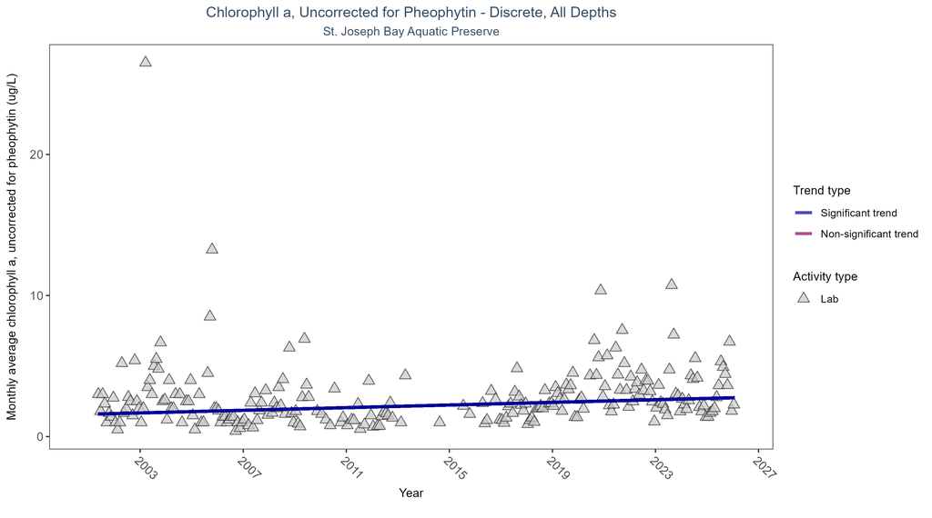

Scatter plot of monthly average levels of chlorophyll a, uncorrected for pheophytin, over time. If the time series included ten or more years of discrete observations, a significant (blue) or non-significant (magenta) trend line is also shown. Only laboratory-analyzed chlorophyll a (triangles) is included in the plot.

Table:

Monthly average chlorophyll a, uncorrected for pheophytin, increased by 0.05 µg/L per year, indicating a decrease in water clarity.

| Activity Type | Statistical Trend | Sample Count | Years with Data | Period of Record | Median Result Value | Tau | Sen Intercept | Sen Slope | P |
| --- | --- | --- | --- | --- | --- | --- | --- | --- | --- |
| Lab | Increasing trend | 1382 | 26 | 2001 - 2026 | 2 | 0.18862 | 1.58388 | 0.04676 | 0.0001 |

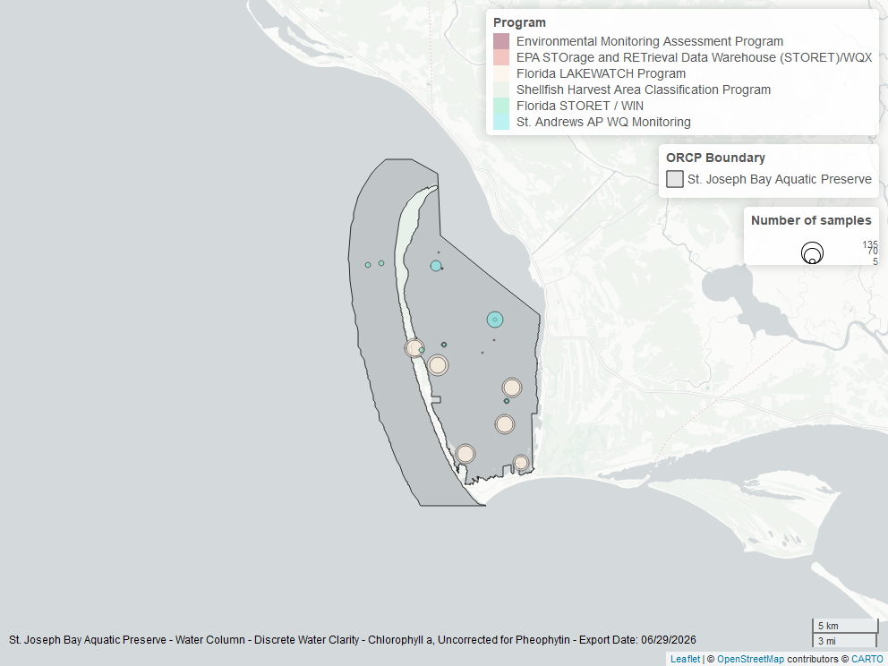

Map showing location of discrete water quality sampling locations within the boundaries of *St. Joseph Bay Aquatic Preserve*. The bubble size on the maps above reflect the amount of data available at each sampling site.

### Chlorophyll a, Corrected for Pheophytin - Discrete

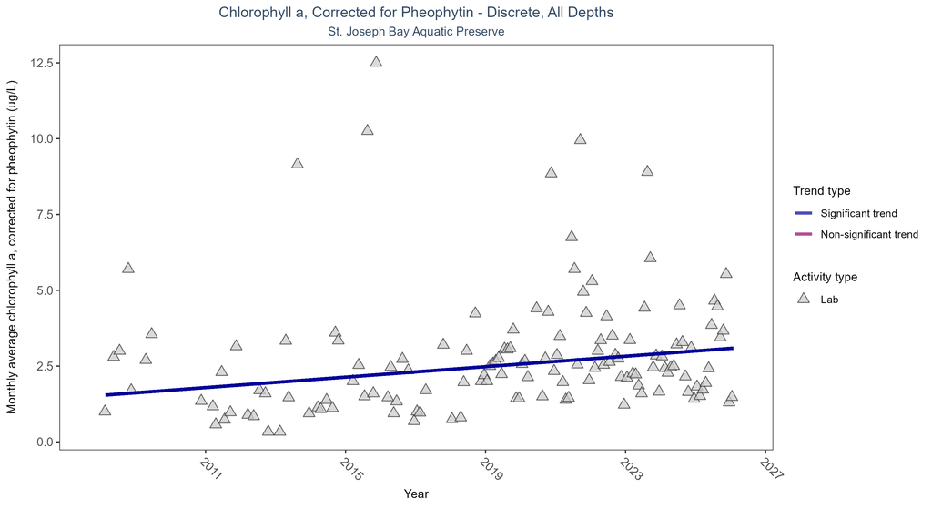

Scatter plot of monthly average levels of chlorophyll a, corrected for pheophytin, over time. If the time series included ten or more years of discrete observations, a significant (blue) or non-significant (magenta) trend line is also shown. Only laboratory-analyzed chlorophyll a (triangles) is included in the plot.

Table:

Monthly average chlorophyll a, corrected for pheophytin, increased by 0.09 µg/L per year, indicating a decrease in water clarity.

| Activity Type | Statistical Trend | Sample Count | Years with Data | Period of Record | Median Result Value | Tau | Sen Intercept | Sen Slope | P |
| --- | --- | --- | --- | --- | --- | --- | --- | --- | --- |
| Lab | Increasing trend | 761 | 19 | 2008 - 2026 | 2.1 | 0.20202 | 1.53252 | 0.08613 | 0.0032 |

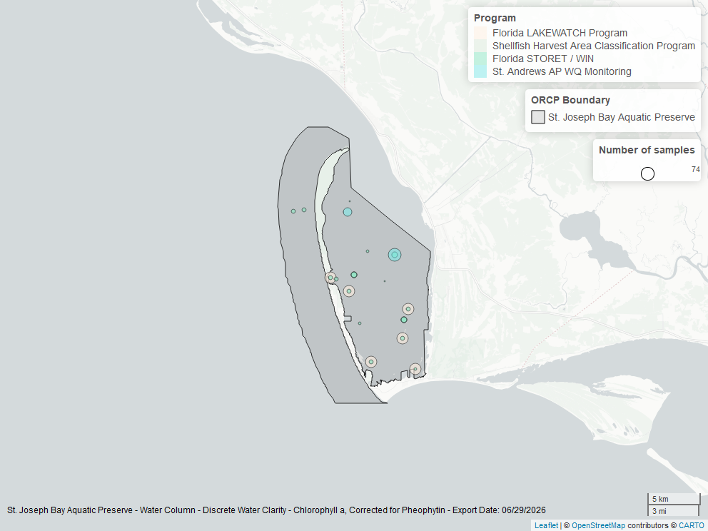

Map showing location of discrete water quality sampling locations within the boundaries of *St. Joseph Bay Aquatic Preserve*. The bubble size on the maps above reflect the amount of data available at each sampling site.

### Secchi Depth - Discrete

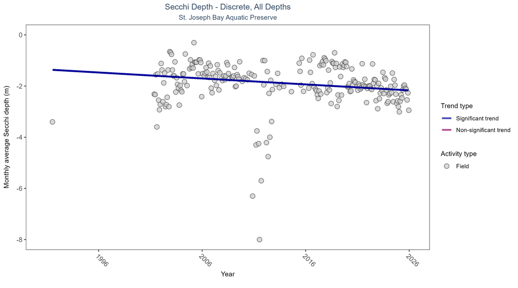

Scatter plot of monthly average Secchi depth over time. If the time series included ten or more years of discrete observations, a significant (blue) or non-significant (magenta) trend line is also shown. Secchi depth is only measured in the field (circles).

Table:

Monthly average Secchi depth became deeper by 0.02 m per year, indicating an increase in water clarity.

| Activity Type | Statistical Trend | Sample Count | Years with Data | Period of Record | Median Result Value | Tau | Sen Intercept | Sen Slope | P |
| --- | --- | --- | --- | --- | --- | --- | --- | --- | --- |
| Field | Decreasing trend | 1858 | 26 | 1991 - 2025 | -1.37162 | -0.20833 | -1.3532 | -0.02331 | 0 |

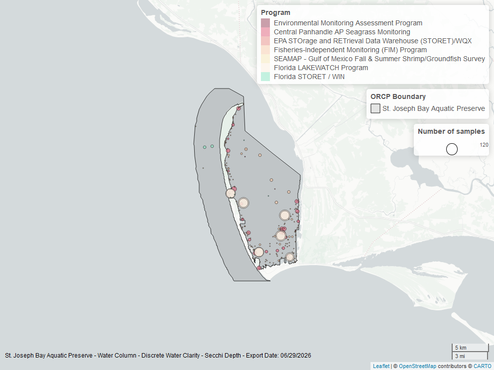

Map showing location of discrete water quality sampling locations within the boundaries of *St. Joseph Bay Aquatic Preserve*. The bubble size on the maps above reflect the amount of data available at each sampling site.

### Colored Dissolved Organic Matter - Discrete

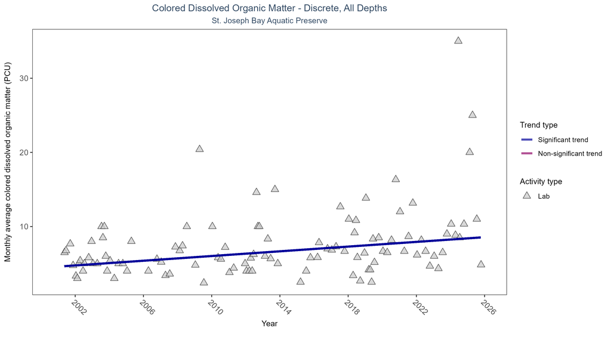

Scatter plot of monthly average colored dissolved organic matter (CDOM) over time. If the time series included ten or more years of discrete observations, a significant (blue) or non-significant (magenta) trend line is also shown. Only laboratory-analyzed CDOM (triangles) is included in the plot.

Table:

Monthly average colored dissolved organic matter increased by 0.16 PCU per year, indicating a decrease in water clarity.

| Activity Type | Statistical Trend | Sample Count | Years with Data | Period of Record | Median Result Value | Tau | Sen Intercept | Sen Slope | P |
| --- | --- | --- | --- | --- | --- | --- | --- | --- | --- |
| Lab | Increasing trend | 468 | 24 | 2001 - 2025 | 6 | 0.27178 | 4.59236 | 0.15882 | 0.0003 |

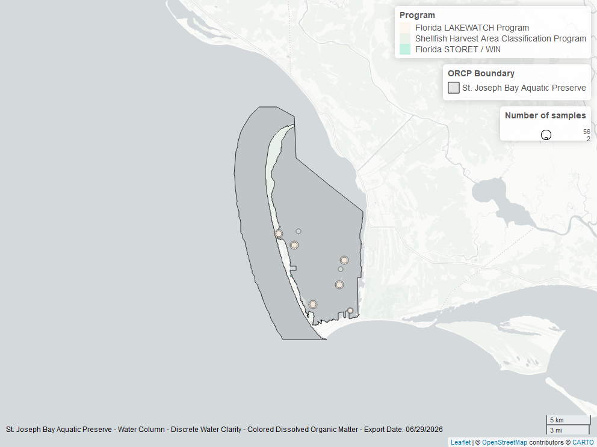

Map showing location of discrete water quality sampling locations within the boundaries of *St. Joseph Bay Aquatic Preserve*. The bubble size on the maps above reflect the amount of data available at each sampling site.